# Roots and Resilience: How Family Adversity Shapes Child and Adult Outcomes

Maliha

2026-09-28

Introduction

This project asks which socioeconomic and behavioral factors are associated with depressive symptoms, and which look protective. It is the first project in a portfolio built around one broader question: what keeps people stuck, and what helps them move forward? Later projects extend that question to biology, intergenerational trauma, and child development.

Here I use NHANES, a national health survey, to build a behavioral and socioeconomic baseline. Through exploratory analysis, I compare how poverty, sleep, physical activity, and gender vary with self-reported depression severity.

Setup

```r
library(tidyverse)
library(NHANES)
library(skimr)
library(reshape2)
```

```r
library(NHANES)
data(NHANES)
glimpse(NHANES)
```

```
## Rows: 10,000
## Columns: 77
## $ ID               <int> 51624, 51624, 51624, 51625, 51630, 51638, 51646, 5164…
## $ SurveyYr         <fct> 2009_10, 2009_10, 2009_10, 2009_10, 2009_10, 2009_10,…
## $ Sex              <fct> male, male, male, male, female, male, male, female, f…
## $ SexOrientation   <fct> Heterosexual, Heterosexual, Heterosexual, NA, Heteros…
## $ Age              <int> 34, 34, 34, 4, 49, 9, 8, 45, 45, 45, 66, 58, 54, 10, …
## $ AgeDecade        <fct>  30-39,  30-39,  30-39,  0-9,  40-49,  0-9,  0-9,  40…
## $ AgeMonths        <int> 409, 409, 409, 49, 596, 115, 101, 541, 541, 541, 795,…
## $ Race1            <fct> White, White, White, Other, White, White, White, Whit…
## $ Race3            <fct> NA, NA, NA, NA, NA, NA, NA, NA, NA, NA, NA, NA, NA, N…
## $ Education        <fct> High School, High School, High School, NA, Some Colle…
## $ MaritalStatus    <fct> Married, Married, Married, NA, LivePartner, NA, NA, M…
## $ HHIncome         <fct> 25000-34999, 25000-34999, 25000-34999, 20000-24999, 3…
## $ HHIncomeMid      <int> 30000, 30000, 30000, 22500, 40000, 87500, 60000, 8750…
```

[output cut: 64 more lines]

**Guiding question:** What socioeconomic and behavioral factors are associated with depression severity, and what looks protective?

First Look at Our Key Variables

```r
NHANES %>%
  select(Age, Gender, Poverty, Depressed, DaysMentHlthBad,
         LittleInterest, SleepTrouble, PhysActive, HHIncomeMid) %>%
  skim()
```

Data summary

| Name | Piped data |
| --- | --- |
| Number of rows | 10000 |
| Number of columns | 9 |
| _______________________ |  |
| Column type frequency: |  |
| factor | 5 |
| numeric | 4 |
| ________________________ |  |
| Group variables | None |

**Variable type: factor**

| skim_variable | n_missing | complete_rate | ordered | n_unique | top_counts |
| --- | --- | --- | --- | --- | --- |
| Gender | 0 | 1.00 | FALSE | 2 | fem: 5020, mal: 4980 |
| Depressed | 3327 | 0.67 | FALSE | 3 | Non: 5246, Sev: 1009, Mos: 418 |
| LittleInterest | 3333 | 0.67 | FALSE | 3 | Non: 5103, Sev: 1130, Mos: 434 |
| SleepTrouble | 2228 | 0.78 | FALSE | 2 | No: 5799, Yes: 1973 |
| PhysActive | 1674 | 0.83 | FALSE | 2 | Yes: 4649, No: 3677 |

**Variable type: numeric**

| skim_variable | n_missing | complete_rate | mean | sd | p0 | p25 | p50 | p75 | p100 | hist |
| --- | --- | --- | --- | --- | --- | --- | --- | --- | --- | --- |
| Age | 0 | 1.00 | 36.74 | 22.40 | 0 | 17.00 | 36.0 | 54.00 | 8e+01 | ▇▇▇▆▅ |
| Poverty | 726 | 0.93 | 2.80 | 1.68 | 0 | 1.24 | 2.7 | 4.71 | 5e+00 | ▅▅▃▃▇ |
| DaysMentHlthBad | 2466 | 0.75 | 4.13 | 7.83 | 0 | 0.00 | 0.0 | 4.00 | 3e+01 | ▇▁▁▁▁ |
| HHIncomeMid | 811 | 0.92 | 57206.17 | 33020.28 | 2500 | 30000.00 | 50000.0 | 87500.00 | 1e+05 | ▃▆▃▁▇ |

The depression question was answered by about two-thirds of respondents (6,673 of 10,000), so the analyses below use those complete responses. Poverty is measured as the ratio of family income to the poverty threshold, so lower values mean more economic hardship and a value of 1 is the poverty line.

Depression Distribution

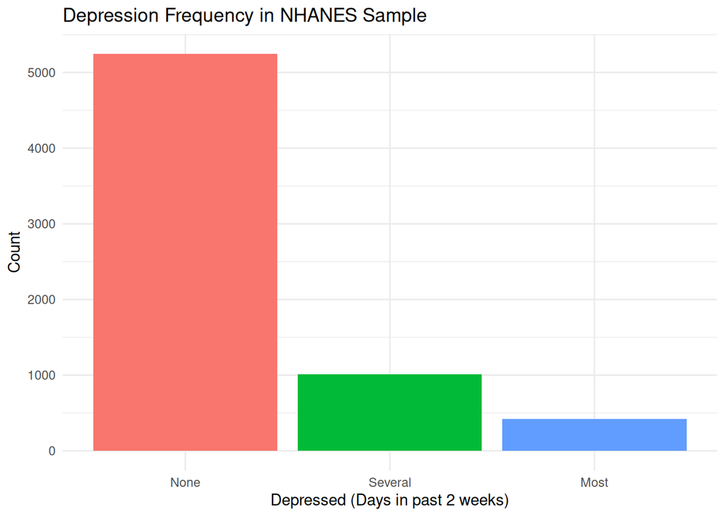

```r
NHANES %>%
  filter(!is.na(Depressed)) %>%
  ggplot(aes(x = Depressed, fill = Depressed)) +
  geom_bar() +
  labs(
    title = "Depression Frequency in NHANES Sample",
    x = "Depressed (Days in past 2 weeks)",
    y = "Count"
  ) +
  theme_minimal() +
  theme(legend.position = "none")
```

Most respondents report no depressive feelings. About 1,000 report feeling down or hopeless on several days and about 420 on most days. Among respondents who answered, that is roughly 21% reporting depressive symptoms on at least several days, a substantial share of the sample.

Depression by Poverty Level

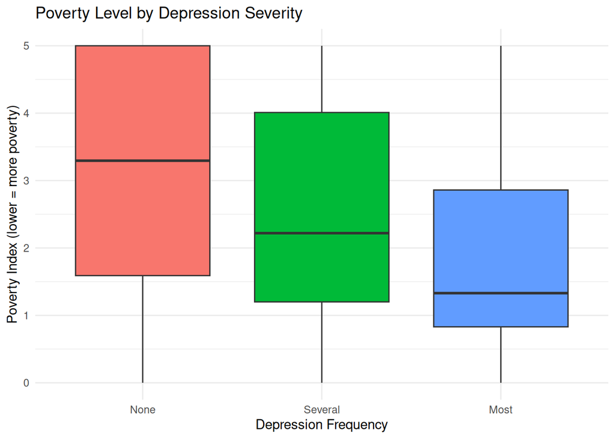

```r
NHANES %>%
  filter(!is.na(Depressed), !is.na(Poverty)) %>%
  ggplot(aes(x = Depressed, y = Poverty, fill = Depressed)) +
  geom_boxplot() +
  labs(
    title = "Poverty Level by Depression Severity",
    x = "Depression Frequency",
    y = "Poverty Index (lower = more poverty)"
  ) +
  theme_minimal() +
  theme(legend.position = "none")
```

What this shows:

The median poverty index falls at each step of depression severity: about 3.3 in the “None” group, about 2.3 in the “Several” group, and about 1.4 in the “Most” group, close to the poverty line.

**Finding 1: Poverty and depression move together.** Respondents reporting depressive feelings on most days have markedly lower poverty index scores than those reporting none. Economic hardship and depressive symptoms travel together in this sample.

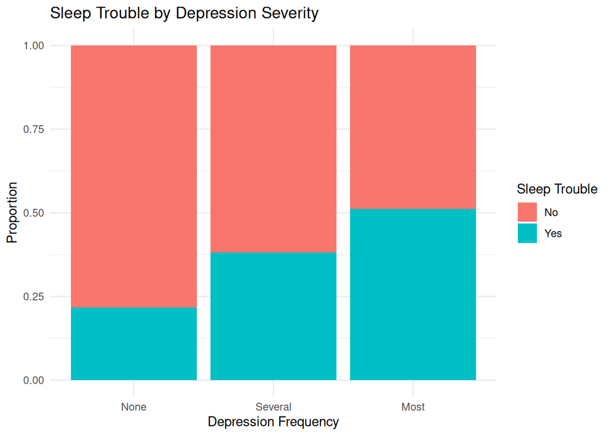

```r
NHANES %>%
  filter(!is.na(Depressed), !is.na(SleepTrouble)) %>%
  ggplot(aes(x = Depressed, fill = SleepTrouble)) +
  geom_bar(position = "fill") +
  labs(
    title = "Sleep Trouble by Depression Severity",
    x = "Depression Frequency",
    y = "Proportion",
    fill = "Sleep Trouble"
  ) +
  theme_minimal()
```

What this shows:

The share reporting sleep trouble rises with depression severity: about 20% in the “None” group, about 38% in the “Several” group, and more than 50% in the “Most” group.

**Finding 2: Sleep trouble rises with depression severity.** Among respondents with depressive feelings on most days, over half also report trouble sleeping, more than double the rate in the “None” group. These data cannot show whether poor sleep contributes to depression, depression disrupts sleep, or both.

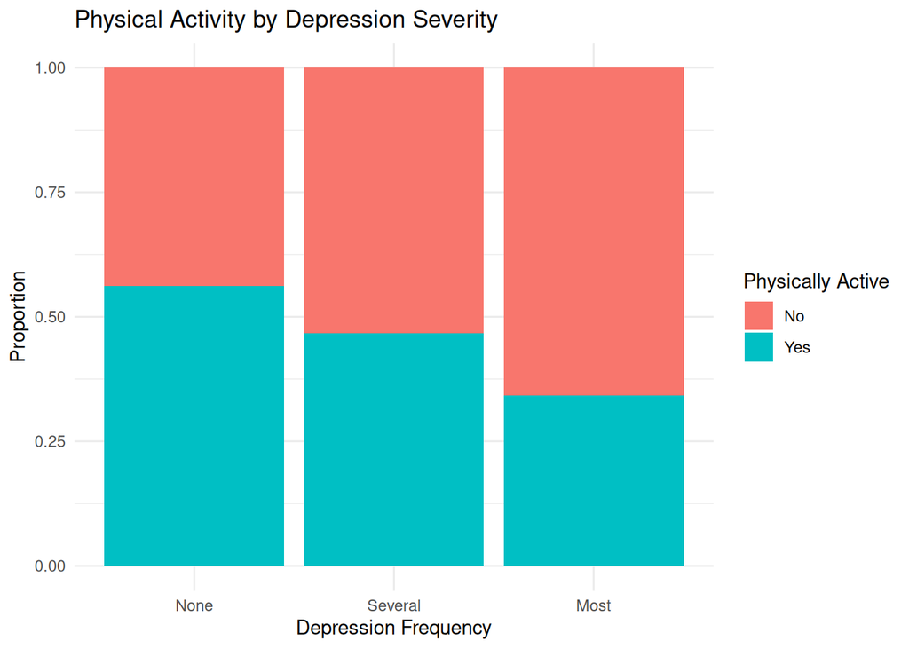

```r
NHANES %>%
  filter(!is.na(Depressed), !is.na(PhysActive)) %>%
  ggplot(aes(x = Depressed, fill = PhysActive)) +
  geom_bar(position = "fill") +
  labs(
    title = "Physical Activity by Depression Severity",
    x = "Depression Frequency",
    y = "Proportion",
    fill = "Physically Active"
  ) +
  theme_minimal()
```

The share who are physically active falls as depression severity rises: about 58% in the “None” group, about 47% in the “Several” group, and about 34% in the “Most” group.

**Finding 3: Physical activity is more common among people with fewer depressive symptoms.** Nearly 6 in 10 respondents with no depressive feelings are physically active, compared with about 1 in 3 of those with symptoms on most days. This is the clearest protective-looking pattern in the analysis, but a snapshot cannot tell us whether activity protects against depression, depression reduces activity, or both.

## Gender and Depression

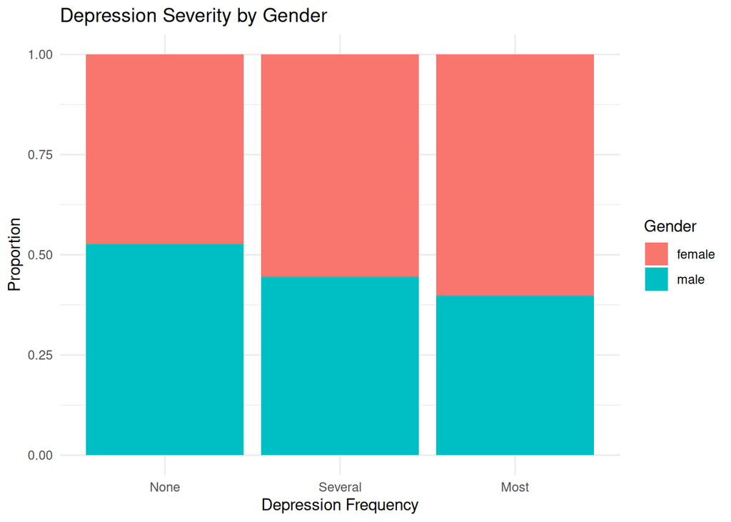

```r
NHANES %>%
  filter(!is.na(Depressed), !is.na(Gender)) %>%
  ggplot(aes(x = Depressed, fill = Gender)) +
  geom_bar(position = "fill") +
  labs(
    title = "Depression Severity by Gender",
    x = "Depression Frequency",
    y = "Proportion",
    fill = "Gender"
  ) +
  theme_minimal()
```

What this shows:

The female share rises with depression severity: just under half in the “None” group, about 55% in the “Several” group, and about 60% in the “Most” group.

**Finding 4: Women are overrepresented at higher severity.** Women make up about 60% of respondents reporting depressive feelings on most days, although the sample is split roughly evenly by gender overall. Possible explanations, such as differences in caregiving burden, economic inequality, or biology, are beyond what this analysis can test.

## Conclusion

### What this analysis shows

In this NHANES sample, more frequent depressive symptoms go along with lower income relative to poverty, more sleep trouble, less physical activity, and a higher share of women. Sleep trouble showed the strongest association (r = 0.21), followed by poverty (r = -0.19), household income (r = -0.18), and physical activity (r = -0.11). Gender (r = 0.07) and age (r = -0.02) showed little. No one factor dominates.

### What this analysis cannot show

- **Causation or direction.** The data are a snapshot, not a timeline. We can say these factors co-occur, not that one causes another.
- **Independent effects.** The analysis is bivariate and the factors overlap (poverty and income especially), so it cannot separate their individual contributions.
- **Clinical depression.** Depression is measured with a single self-report item about feeling down or hopeless.

### What comes next

Project 2 moves from behavioral correlates to biology, examining differential gene expression in major depressive disorder (GEO dataset GSE98793, analyzed with DESeq2). Later projects examine epigenetic mechanisms of intergenerational trauma using DNA methylation data, and developmental outcomes and family environment using the ABCD Study.

## Summary: How All Factors Relate

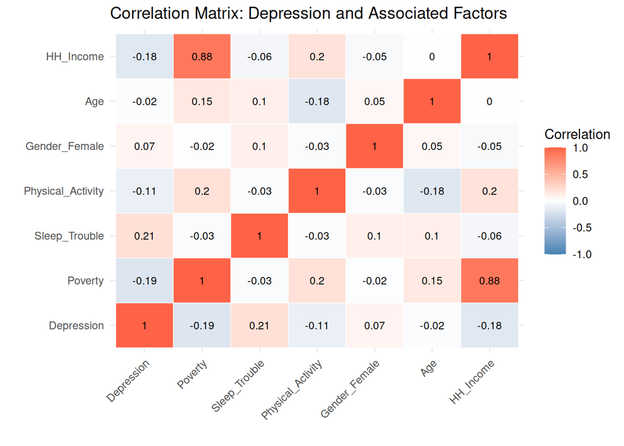

```r
library(reshape2)

# Create numeric version of key variables
nhanes_numeric <- NHANES %>%
  filter(!is.na(Depressed), !is.na(Poverty),
         !is.na(SleepTrouble), !is.na(PhysActive),
         !is.na(Gender)) %>%
  mutate(
    Depressed_n = as.numeric(Depressed),
    SleepTrouble_n = ifelse(SleepTrouble == "Yes", 1, 0),
    PhysActive_n = ifelse(PhysActive == "Yes", 1, 0),
    Gender_n = ifelse(Gender == "female", 1, 0)
  ) %>%
  select(
    Depression = Depressed_n,
    Poverty = Poverty,
    Sleep_Trouble = SleepTrouble_n,
    Physical_Activity = PhysActive_n,
    Gender_Female = Gender_n,
    Age = Age,
    HH_Income = HHIncomeMid
  )

# Correlation matrix
cor_matrix <- cor(nhanes_numeric, use = "complete.obs")

# Melt and plot
melted_cor <- melt(cor_matrix)

ggplot(melted_cor, aes(x = Var1, y = Var2, fill = value)) +
  geom_tile(color = "white") +
  scale_fill_gradient2(
    low = "steelblue", mid = "white", high = "tomato",
    midpoint = 0, limit = c(-1, 1),
    name = "Correlation"
  ) +
  geom_text(aes(label = round(value, 2)), size = 3) +
  labs(
    title = "Correlation Matrix: Depression and Associated Factors",
    x = "", y = ""
  ) +
  theme_minimal() +
  theme(axis.text.x = element_text(angle = 45, hjust = 1))
```

The depression row of the matrix summarizes how each factor relates to depression severity:

- **Sleep trouble (r = 0.21):** the strongest positive association
- **Poverty index (r = -0.19):** lower poverty index, meaning more hardship, goes with more depression
- **Household income (r = -0.18):** lower income goes with more depression
- **Physical activity (r = -0.11):** less activity goes with more depression
- **Gender, female (r = 0.07):** a small female skew
- **Age (r = -0.02):** essentially no relationship

Poverty index and household income are strongly correlated with each other (r = 0.88) because both measure economic resources, so they should be read as overlapping rather than independent factors.

**Finding 5: No single factor dominates.** Sleep trouble showed the strongest association with depression, followed by poverty, household income, and physical activity. All correlations are modest (|r| of 0.21 or less), which suggests depressive symptoms are linked to several overlapping burdens, economic, physiological, and behavioral, rather than to any one cause. If that holds, interventions that address only one factor may fall short.

## Finding 5: Summary — What Matters Most

The correlation matrix confirms and quantifies the patterns observed throughout this analysis. Sleep trouble shows the strongest individual relationship with depression (r = 0.21), followed closely by poverty (r = -0.19) and household income (r = -0.18). Physical activity shows a modest protective relationship (r = -0.11). Gender shows a small but consistent female skew (r = 0.07).

Notably, no single factor dominates. Depression appears to be distributed across multiple compounding burdens — economic, physiological, and behavioral — rather than driven by any one cause. This has direct implications for intervention: addressing only one factor may be insufficient.